# M.3.Unsupervised - Iris dataset - Davis Zakary

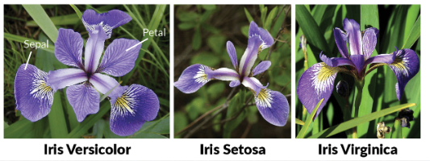

## Overview - Iris Assignmment

### Objectives

Use the provided data analysis stages to perform exploratory activities on the Fisher Iris dataset leading to quality predictive outcomes.

How To

1. Organize and present your analysis.
- Understand that analysis is iterative, and stages may overlap.
- Consolidate your methodology, providing a clear and precise story.
- There is no need to provide presentations or documents.
2. Craft and modify code to solve questions.
3. Use all algorithms listed below.
4. Use resources and apply methods to solve challenges.
5. Submit work with the correct file name. `note:` Typically, "scaling" is included in machine learning. Due to algorithm quantity, it was separated as stage.3 to help organize analysis work.

### Tasks

- Stage 1: Data Preparation
- Stage 2: Feature Extraction
- Stage 3: Data Scaling
- Stage 4: Machine Learning and Evaluation
- Stage 5: Visualization

### Background, data, and methods

- https://en.wikipedia.org/wiki/Iris_flower_data_set
- https://www.kaggle.com/datasets/uciml/iris?resource=download
- https://scikit-learn.org/stable/auto_examples/datasets/plot_iris_dataset.html
- https://scikit-learn.org/stable/modules/generated/sklearn.preprocessing.StandardScaler.html
- https://scikit-learn.org/stable/modules/generated/sklearn.metrics.accuracy_score.html

### Algorithms

1. K-Means Clustering
2. Hierarchical Clustering
3. Density-Based Spatial Clustering of Applications w Noise
4. Isolation Forest
5. Local Outlier Factor
6. Principal Component Analysis
7. Singular Value Decomposition
8. T-Distributed Stochastic Neighbor Embedding With Autoencoder
9. Singular Value Decomposition

## Task.Warmup

- Warm.up.1 - locate and read the source paper
  - Fisher, R.A. (1936). classic 1936 paper, The Use of Multiple Measurements in Taxonomic Problems. Annuals of Eugenics, Vol.7, Iss.2.
- Warm.up.2 - detail 1 interesting fact or learning from the 11 page paper
- Warm.up.3 - Referring to Fig.1 Frequency Histogram what, algorithm
  - "should"help indicate or determine if Iris setosa has an outlier?
  - provide a rapid or gut response based on your canvas learnings.

**Student Response**

An outlier detection method such as local outlier factor could determine if there is an outlier for setosa. This method pays attention to local groupings. Unlike using IQR, this method will find outliers for each group.

## `Stage.1.Data.Prepartion`

**`Tasks`**

1. Stage.1.Task.1 - What data is concerning?
2. Stage.1.Task.2 - Are transformations needed?
3. Stage.1.Task.3 - Write 2-5 points explaining learnings to another.

**`Useful links`**

- https://pandas.pydata.org/docs/reference/
- https://scikit-learn.org/stable/modules/preprocessing.html
- https://scikit-learn.org/stable/modules/generated/sklearn.decomposition.PCA.html

**`Hints`**

- `Iris` is `notoriously tricky` for outlier visualization. => `Try` principal components analysis, reducing features to 2 dimensions

### Stage.1.Task => ALL

```python
import numpy as np
import pandas as pd
import matplotlib.pyplot as plt
from adodbapi.ado_consts import adCurrency
from sklearn.decomposition import PCA
from sklearn.neighbors import LocalOutlierFactor
```

```python
df = pd.read_csv('https://raw.githubusercontent.com/cosc-526/home.page/refs/heads/main/data.M.3.assignment.Iris.csv')
```

```python
#=> Stage.1.Task.1 - What data is concerning?
print('Columns info and Non-Null Count:')
print(df.info())

print('\nUnique Species:')
species = df['species'].unique()
print(species)

print('\nMissing Values:')
print(df.isnull().sum())
```

```
Columns info and Non-Null Count:
<class 'pandas.core.frame.DataFrame'>
RangeIndex: 150 entries, 0 to 149
Data columns (total 5 columns):
 #   Column        Non-Null Count  Dtype
---  ------        --------------  -----
 0   sepal_length  150 non-null    float64
 1   sepal_width   150 non-null    float64
 2   petal_length  150 non-null    float64
 3   petal_width   150 non-null    float64
 4   species       150 non-null    object
dtypes: float64(4), object(1)
memory usage: 6.0+ KB
None

Unique Species:
['setosa' 'versicolor' 'virginica']

Missing Values:
sepal_length    0
sepal_width     0
petal_length    0
petal_width     0
species         0
dtype: int64
```

```python
df_no_species = df.drop('species', axis=1)
for column in df_no_species.columns:
    df_no_species[column] = (df[column] - df[column].mean()) / df[column].std()
print(df.describe())
print(df_no_species.describe())
```

```
       sepal_length  sepal_width  petal_length  petal_width
count    150.000000   150.000000    150.000000   150.000000
mean       5.843333     3.054000      3.758667     1.198667
std        0.828066     0.433594      1.764420     0.763161
min        4.300000     2.000000      1.000000     0.100000
25%        5.100000     2.800000      1.600000     0.300000
50%        5.800000     3.000000      4.350000     1.300000
75%        6.400000     3.300000      5.100000     1.800000
max        7.900000     4.400000      6.900000     2.500000
       sepal_length   sepal_width  petal_length   petal_width
count  1.500000e+02  1.500000e+02  1.500000e+02  1.500000e+02
mean  -5.684342e-16 -6.158037e-16  1.894781e-16 -1.894781e-16
std    1.000000e+00  1.000000e+00  1.000000e+00  1.000000e+00
min   -1.863780e+00 -2.430844e+00 -1.563497e+00 -1.439627e+00
25%   -8.976739e-01 -5.858010e-01 -1.223442e+00 -1.177559e+00
50%   -5.233076e-02 -1.245404e-01  3.351431e-01  1.327811e-01
75%    6.722490e-01  5.673506e-01  7.602119e-01  7.879511e-01
max    2.483699e+00  3.104284e+00  1.780377e+00  1.705189e+00
```

```python
iris_pca = PCA(n_components=2)
pca_data = iris_pca.fit_transform(df_no_species)
print(iris_pca.explained_variance_ratio_)
print(iris_pca.explained_variance_)
```

```
[0.72770452 0.23030523]
[2.91081808 0.92122093]
```

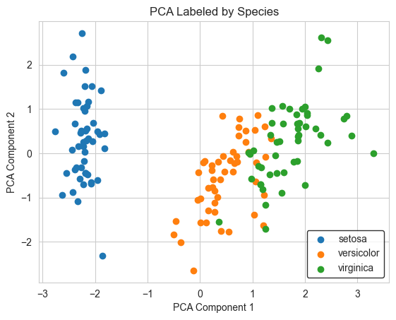

```python
for name in species:
    idx = (df['species'] == name).to_numpy()
    plt.scatter(pca_data[idx, 0], pca_data[idx, 1], label=name)
plt.title('PCA Labeled by Species')
plt.legend(edgecolor='black')
plt.xlabel('PCA Component 1')
plt.ylabel('PCA Component 2')
plt.show()
```

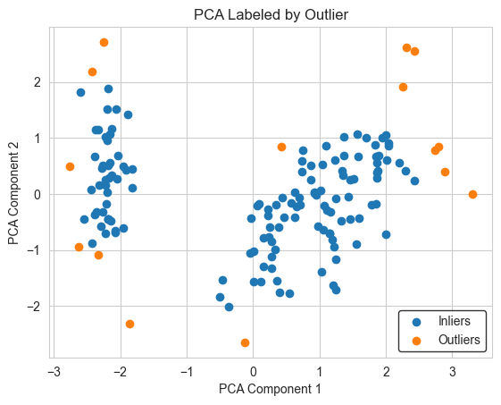

```python
estimator = LocalOutlierFactor(n_neighbors=10)
# pca_outlier_data = np.zeros((pca_data.shape[0], 3))
# pca_outlier_data[:, 0:2] = pca_data
# species_map = {'setosa': 0, 'versicolor': 1, 'virginica': 2}
# pca_outlier_data[:, 2] = df['species'].map(species_map)
outliers = estimator.fit_predict(pca_data)

plt.scatter(pca_data[outliers==1, 0], pca_data[outliers==1, 1], label='Inliers')
plt.scatter(pca_data[outliers==-1, 0], pca_data[outliers==-1, 1], label='Outliers')
plt.legend(edgecolor='black')
plt.xlabel('PCA Component 1')
plt.ylabel('PCA Component 2')
plt.title('PCA Labeled by Outlier')
plt.show()
```

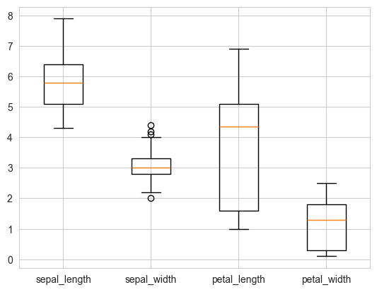

```python
tmp = df.drop('species', axis=1)
plt.boxplot(
    x=tmp,
    tick_labels=tmp.columns,
)
plt.show()
```

### Stage 1 Task 3

This dataset contains information regarding the length and width of the sepal and petal for flowers of three different species. There are 150 observations, none of which have null values. A simple PCA with 2 dimensions explains ~95% of the variance in the dataset. When plotting the PCA components, we can label by species to see that setosa is distinctly different from the other two species.